# Frederick Solt

##### Income Inequality & Its Consequences, Comparative Political Behavior, and Dynamic Comparative Public Opinion

# Updates and Working Notes

### SWIID Version 6.1 is available!

##### Friday, 27 October 2017

Version 6.1 of the SWIID is [now available](http://fsolt.org/swiid/swiid_downloads.html)! Building on the end-to-end revision accomplished in Version 6.0 last July, this new release:

- incorporates in [its source data](https://github.com/fsolt/swiid/blob/master/data/swiid_source.csv) 280 new Ginis, including [newly available LIS data on Canada and Lithuania](http://www.lisdatacenter.org/news-and-events/fall-data-release/);
- includes estimates of disposable income inequality for 83 new country-years;
- expands estimates of market income inequality to *all* country-years (version 6.0 only estimated market income inequality for countries included in the LIS, about a third of the total country-years);
- calculates estimates of absolute and relative redistribution for twenty additional countries, for a total of sixty-six—all of the countries for which there is source data available [on both the distribution of market income and the distribution of disposable income or consumption](http://fsolt.org/blog/2015/10/05/redistribution-observations.html).

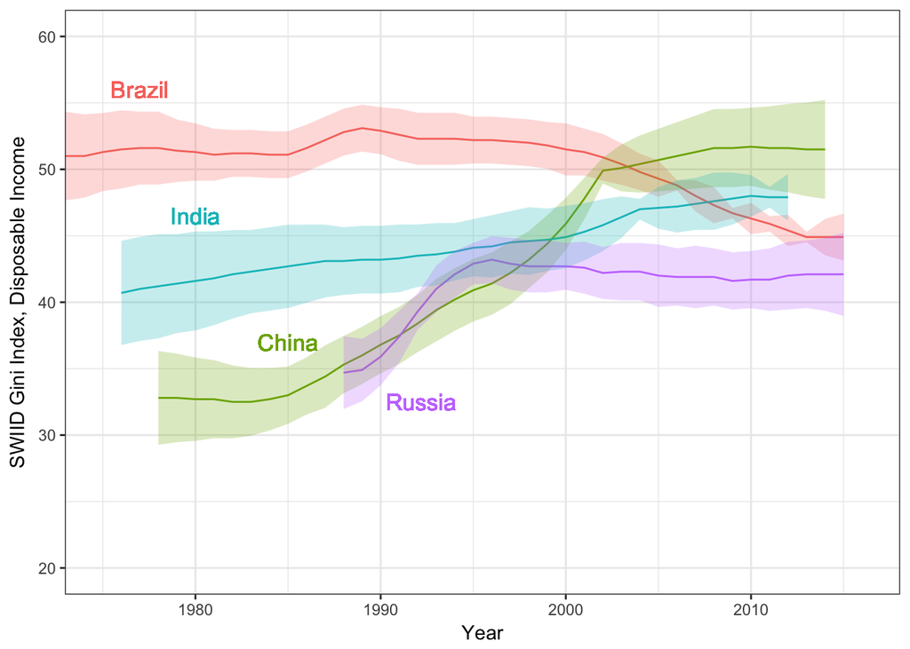

For more details, you can check out the all the R and Stan code used to generate the estimates [in the SWIID GitHub repository](https://github.com/fsolt/swiid). As always, I encourage users of the SWIID to email me with their comments, questions, and suggestions.

### The SWIID Source Data

##### Friday, 28 July 2017

*Friday, 27 October 2017: Updated with information on the source data for SWIID Version 6.1*

I have been producing the Standardized World Income Inequality Database for nearly a decade. Since 2008, the SWIID has provided estimates of the Gini index of income inequality[^1] for as many countries and years as possible and—given the primary goal of maximizing spatial and temporal coverage—these estimates are as comparable as the available data allow. The dataset has been used widely by academics, journalists, and policymakers. It’s been successful way beyond all my hopes.[^2] I’ve been [adding to it, revising it, improving on it](http://fsolt.org/swiid/swiid_downloads.html) pretty much the entire time since its launch. Now, [with the support of the NSF](https://www.nsf.gov/awardsearch/showAward?AWD_ID=1533746), I scrapped all of that work and starting fresh. From scratch.

This is the first in a series of posts on how I did it. It focuses on an unheralded but foundational part of the SWIID project, the source data. The basic idea behind the SWIID is to start with the data that has been most carefully picked over to ensure its utmost cross-national comparability: the data of the fantastic [Luxembourg Income Study](http://www.lisdatacenter.org). I’ve heard that generating a single country-year of LIS data takes an average of ten person-months of work. *That’s* dedication to comparability. ❤️ But the flipside of maximizing comparability is that the LIS’s coverage is pretty sparse: it includes fewer than 300 country-years at last count.[^3] To address this weakness, the SWIID routine estimates the relationships between Gini indices based on the LIS and all of the other Ginis available for the same country-years, then uses these relationships to estimate what the LIS Gini *would be* in country-years not included in the LIS but available from other sources.[^4] The critical first step to making this work is getting *a lot* of other, non-LIS Ginis. I call these other Ginis the SWIID’s source data. Over the years, I and my research assistants built up a big spreadsheet of data collected from international organizations, national statistical offices, and scholarly books and articles. But it seemed like whenever I checked over these source data, I would find that at least a few figures had been recently revised, or their source was seemingly no longer available, or (worst of all) they evidently had been entered incorrectly. So again: it’s time to start over from scratch.

To be included in the SWIID’s source data, observations need to encompass the entire population of a country without regard to age, location,[^5] or employment status.[^6] They need to have an identifiable welfare definition and equivalence scale (more on these below). Finally, because I want to be able to direct users to sources they can easily peruse themselves, observations need to be available online.[^7]

Hand-entering data is tedious and error-prone work, so I [automated as much of the process of data collection](https://github.com/fsolt/swiid/blob/master/R/data_setup.R) as practicable. Most international organizations and a few national statistical offices use APIs that facilitate downloading their data, and often the [#rstats](https://twitter.com/search?q=%23rstats) community has built R packages using these APIs to make the task even easier. I took as much advantage of these resources as possible.[^8] In the absence of an API, I scripted downloads of any available spreadsheets, preferring clean csv files to excel-formatted ones. If there was no spreadsheet, but data were available in pdf files, I automated downloading these files and then used [Thomas Leeper](http://thomasleeper.com)’s [`tabulizer` package](https://github.com/ropensci/tabulizer) to read the tables into R. In the absence of a file to download, I scripted the process of scraping the data from the web. Still, for a variety of reasons, a source’s data may have been consigned to being entered in a [separate spreadsheet](https://github.com/fsolt/swiid/blob/master/data-raw/article_data/fs_added_data.csv). Many sources contain just a handful or fewer observations, making the payoff to the often laborious process of data cleaning too small to justify the effort. Some sources–including most academic articles–are behind paywalls, making reproducibility a hassle anyway (though I still often used tabulizer to read the data from the pdf before cutting-and-pasting it into the spreadsheet). Some sources, like books, or the .doc file(!) generated annually by [New Zealand’s Ministry of Social Development](http://www.msd.govt.nz/about-msd-and-our-work/publications-resources/monitoring/household-incomes/index.html), cannot be read straight into R. Finally, at least [one source](https://wdronline.worldbank.org/bitstream/handle/10986/9269/wps4007.pdf?sequence=1) contains crucial information encoded in the typeface(!!) of its tables, information lost when the tables are scanned into R. All of the entries in this spreadsheet were checked repeatedly for errors,[^9] and I excluded repeated reports of the exact same observation from different sources. In the end, I was able to automate the collection of more than three quarters of the source data and a much higher percentage of the series that will be updated or are subject to revision, facilitating incorporating these changes in future versions.

The resulting dataset comprises 13670(!) Gini coefficients from 2753 country-years in 192 countries or territories, making the coverage of the SWIID source data broader than that of any other income inequality dataset. This isn’t surprising given that, with the exceptions of the [WIID](https://www.wider.unu.edu/database/world-income-inequality-database-wiid34) (which isn’t drawn on at all anymore) and the All the Ginis database (which isn’t drawn on much), the SWIID source data incorporates all of the data in these other datasets.

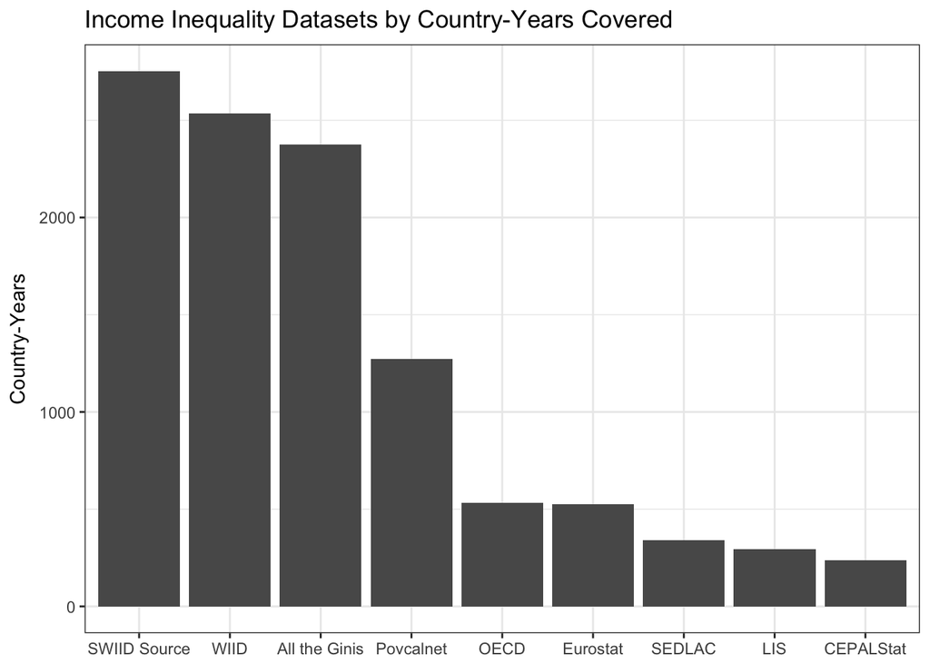

So, let’s check out what the source data look like. There is much more data available about the income distribution in some countries than in others. Which countries are most data-rich? The plot below shows the top dozen countries by the count of observations. Canada, by virtue of the excellent [Statistics Canada](http://www.statcan.gc.ca) as well as longstanding membership in the OECD and LIS, has 727 observations, many more than any other country. The United Kingdom and United States are next, followed by an interesting mix countries from around the world with not surprisingly a sizable European representation. All are members of the LIS. On the other hand, eleven countries have only a single observation.

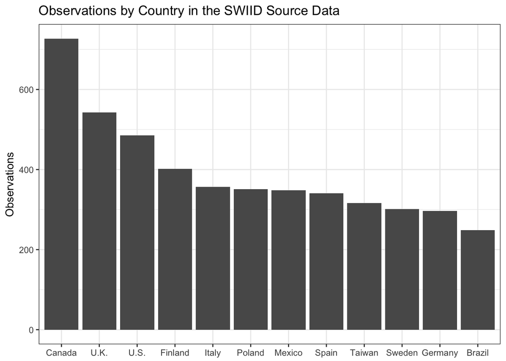

As we’ll see in later posts in this series, observations for the same country in the same year, but with different welfare definitions and equivalence scales or from different sources, are important to generating the SWIID’s cross-nationally comparable estimates. Still, we might be interested to know which countries have the most coverage of the years in the SWIID’s current 57-year timeframe, from 1960 to 2016, because the SWIID’s inequality estimates for countries with fewer country-year observations will include more interpolated values, which in turn will have more uncertainty.

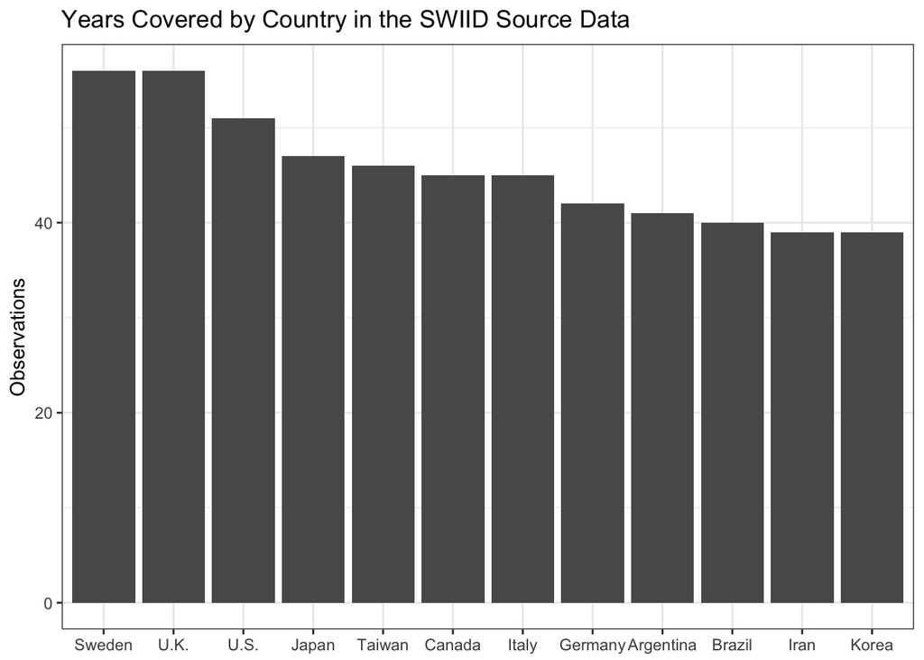

The source data includes observations for Sweden and the United Kingdom in all but one of these years and for the United States in all but six. Argentina—a country not included in the LIS—makes the top 12, with 41 country-year observations. The median country has observations in just eleven different country-years.

We can also get a sense of the available inequality data by turning the question around and asking about coverage across countries over time. There are observations for 122 countries in 2005. Coverage is relatively good in the years from 2000 to 2014, at least 80 countries per year, before dropping to 75 countries for 2015 and just 11 for last year. Country coverage is pretty thin each year through the 1960s and 1970s and still isn’t all that great until the late 1980s.[^10]

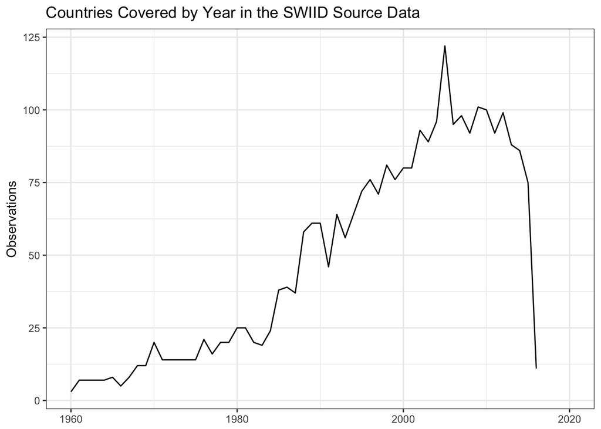

Earlier I mentioned that to be included in the SWIID source data observations need to have an identifiable welfare definition and equivalence scale. A welfare definition is an answer to the question, this Gini measures the distribution of what? The four welfare definitions employed in the SWIID source data are market income, gross income, disposable income, and consumption. Market income is defined as amount of money coming into the household, excluding any government cash or near-cash benefits, the so-called ‘pre-tax, pre-transfer income.’[^11] Gross income is the sum of market income and government transfer payments; it is ‘pre-tax, post-transfer income.’ Disposable income, in turn, is gross income minus direct taxes: ‘post-tax, post-transfer income.’[^12] Consumption does not refer to the money coming into the household at all but rather to the money going out.[^13] In the source data, Ginis of disposable income are much more common than those using other welfare definitions.

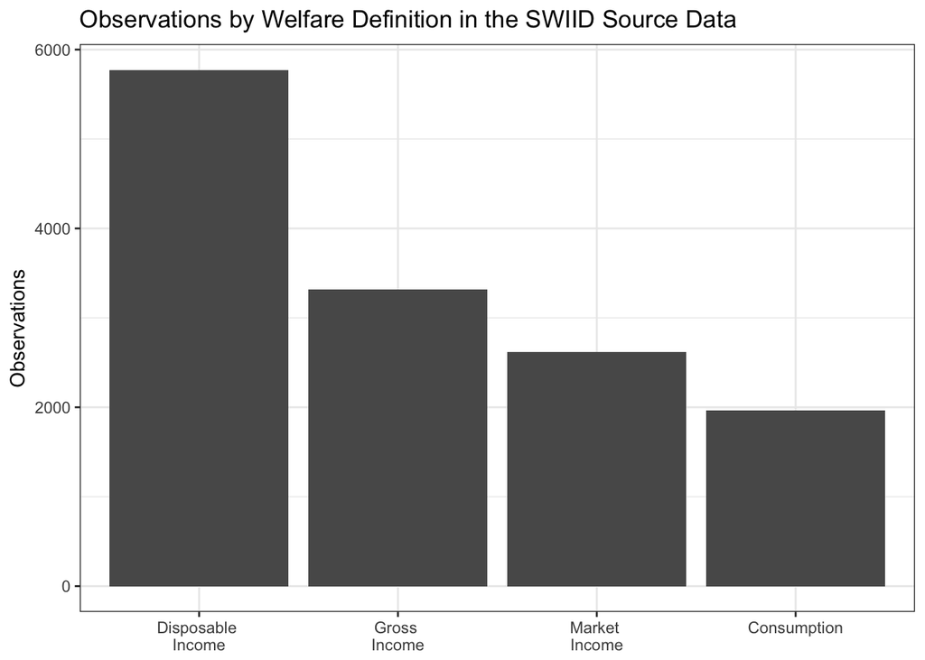

Equivalence scales are the ways in which the size and composition of a household is incorporated into the calculation of its members’ welfare. On the one hand, these factors can simply be ignored, with all households with the same amount of income or consumption treated as if they enjoy the same level of welfare, regardless of their size. One can improve on this household ‘scale’[^14] by dividing the household’s income by its number of members, that is, by using a per capita scale. But a household of two members and an income of $100,000 is better off than one with a single member and $50,000 due to economies of scale—that’s the big reason why people look for roommates. There are a variety of ways to try to account for these economies by calculating the number of “equivalent adults” in the household. Of the most commonly used adult-equivalent scales, the square-root scale is the most straightforward: one simply divides the household income by the square root of the number of members. The “OECD-modified” scale for the number of adult equivalents ([which the OECD actually no longer uses](http://www.oecd.org/eco/growth/OECD-Note-EquivalenceScales.pdf)) counts the first adult as 1, all other adults as .5, and each child as .3. And there are plenty of other adult-equivalent scales, from the “old OECD” scale (1 for the first adult, 0.7 for each additional adult, and 0.5 for each child) to caloric-requirement-based scales (which are actually very nearly per capita, as it turns out) to a number of country-specific scales. In previous versions of the SWIID, all adult-equivalent scales were considered a single category. Now, the square-root scale and the OECD-modified scale have both been split out, leaving the remaining catch-all adult-equivalent category much smaller.

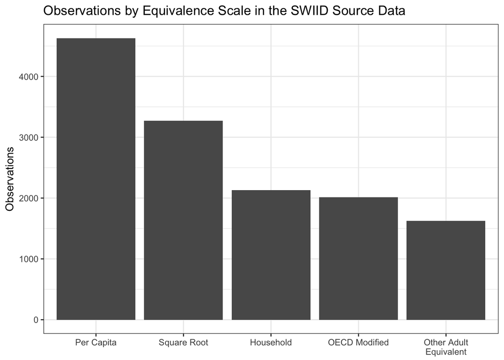

Differences in the welfare definition and the equivalence scale employed constitute the biggest source of incomparability across observations in the source data, and all twenty of the possible combinations are represented. I’ll take up how we get from these incomparable observations to the SWIID estimates in the next post. In the meantime, if you’d like to see the source data, you can [download it from here](https://github.com/fsolt/swiid/blob/master/data/swiid_source.csv).

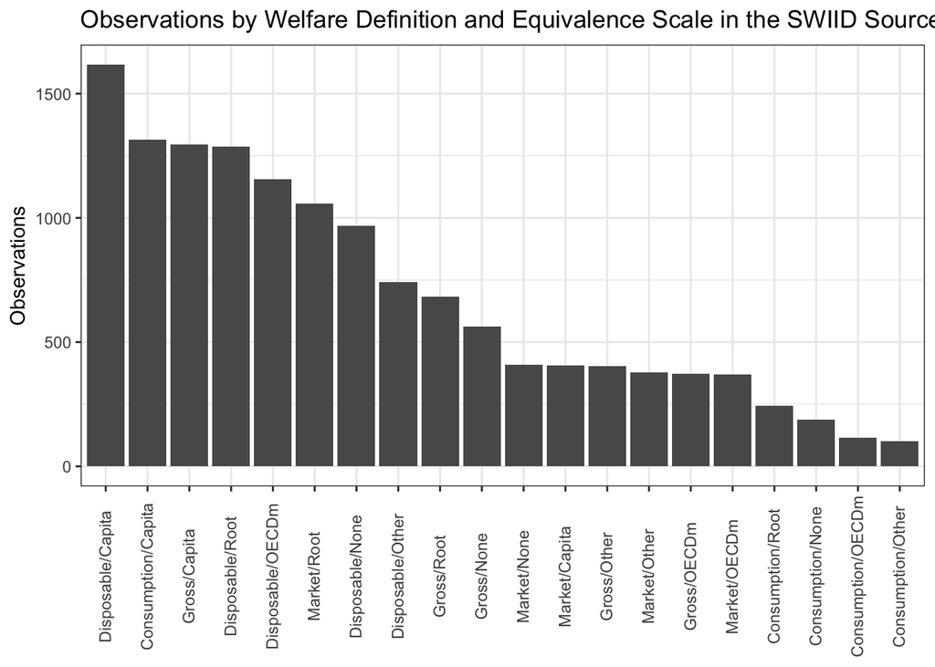

# References

Jesuit, David K., and Vincent A. Mahler. 2010. “Comparing Government Redistribution Across Countries: The Problem of Second-Order Effects.” *Social Science Quarterly* 91(5): 1390–1404.

Morgan, Jana, and Nathan J. Kelly. 2013. “Market Inequality and Redistribution in Latin America and the Caribbean.” *Journal of Politics* 75(3): 672–85.

Solt, Frederick. 2016. “The Standardized World Income Inequality Database.” *Social Science Quarterly* 97(5): 1267–81.

[^1]: I think the clearest explanation of the Gini index is that it is half the average difference in income between all pairs of units—say, households—as a percentage of the mean income of those units. Okay, I said “clearest,” not necessarily “clear.” Anyway, it has a theoretical range of 0 (all households have the same income) to 100 (one household has all the income and the rest have none), but Ginis below 20 or above 60 are rare in the real world. There are good reasons to prefer other measures of inequality, and there are many options, but the Gini is by far the most widely available.
[^2]: At the time, those hopes were admittedly concerned mostly with getting [#Reviewer2](https://twitter.com/search?q=%23reviewer2&src=typd) off my back so I could publish a [series](http://fsolt.org/papers/solt2011) [of](http://fsolt.org/papers/solthabelgrant2011) [manuscripts](http://fsolt.org/papers/solt2012) I had on how the context of inequality is related to people’s political attitudes.
[^3]: Which is what #Reviewer2 always complained about. R2: Shouldn’t you include [Ruritania and Megalomania](https://en.wikipedia.org/wiki/Ruritania#In_academia) in your sample, given the broad applicability of your theory? Me: Yes, sure, but like I wrote in the paper, there’s no LIS data for those countries, and the other available data just isn’t comparable. R2: Well then, I recommend rejection. Me: Grr.
[^4]: If you’re thinking, “hey, multiple imputation for missing data,” cool, that’s what I was thinking too. If you’re thinking of [poll aggregators and house effects](https://projects.fivethirtyeight.com/congress-generic-ballot-polls/), yep, it’s very similar. If you’re thinking of inequality as a latent variable, with a number of indicators of varying discrimination, that also works. If you’re thinking you need to look at some cat gifs right about meow, [click here](https://giphy.com/search/cat).
[^5]: The requirement for complete territorial coverage was relaxed for minor deviations such as data on Portugal that excludes Madeira and the Azores. It was relaxed somewhat further for early series that covered only the urban population of three highly urbanized countries: Uruguay, Argentina, and South Korea. The general rule, however, is that data is excluded if it measures the income distribution of only urban or rural populations, or of only selected cities, or some other such incomplete territory.
[^6]: This last requirement is new; it means nearly 600 observations on the distribution of wages across employed individuals that were included in the source data of previous versions of the SWIID are now excluded. Between the lack of information on those out of the workforce and on how workers formed households, these data weren’t very strongly related to the LIS anyway.
[^7]: For scholarly articles, I preferred DOIs or JSTOR stable URLs, but if those were unavailable I used the publisher website or another repository. For books, I provide the link to the relevant page in Google Books. There were [two](https://books.google.com/books?id=zaL4CGdjOkUC) [books](https://books.google.com/books?id=_aapAgAAQBAJ) that I decided I had to include for which Google Books wouldn’t show the relevant pages (at least not to me); in those two cases, the links I provide just go to the entire volume. I confirmed that the cited pages can be found using Amazon’s “Look Inside” feature, so I consider my “must be available online” rule only badly bent rather than completely broken.
[^8]: Although the sources with APIs were relatively few, they contained the most data: nearly half of the observations were collected this way.
[^9]: Which, of course, is not to say that they are error-free. If you spot any problems, or better still, know of sources I might have missed, *please* [let me know](https://github.com/fsolt/swiid/issues/6)!
[^10]: This is partly a result of my decision to insist on sources that are available online, but it’s just as well: so little information is available about many of the so-excluded observations on that era that I find it hard to have much confidence in them.
[^11]: It’s important, though, to not think of the distribution of market income as ‘pre-government.’ Beyond taxes and transfers, governments seeking to shape the distribution of income have a wide array of ‘market-conditioning’ or ‘predistribution’ policy options, with minimum wage regulation and labor policy two obvious examples (see, e.g., Morgan and Kelly 2013). Further, even taxes and transfers can profoundly shape the distribution of *market* income through ‘second-order effects.’ Where robust public pension programs exist, for example, people save less for retirement, leaving many of the elderly without market income in old age and so raising the level of market-income inequality (see, e.g., Jesuit and Mahler 2010).
[^12]: Note that disposable income still does not take into account, on the one hand, indirect taxes like sales taxes and VAT, or, on the other, public services and indirect government transfers such as price subsidies. There is very little information available about the distribution of such ‘final income,’ pretty much only that generated by the [Commitment to Equity Institute](http://www.commitmentoequity.org), so I exclude it from the SWIID source data at least for the time being.
[^13]: In previous versions of the SWIID, market and gross income were treated as a single welfare definition, and I am glad to finally be able to split them apart (c.f., Solt 2016, 1272). The consumption welfare definition *might* now be the most heterogeneous within the SWIID source data, varying considerably in whether and how observations treat expenditures on durable goods. Another source of differences within a single welfare definition is the extent to which nonmonetary income—such as the value of food grown for the household’s own consumption or of housing that the owner occupies—is included. The SWIID source data include the variable `monetary` that indicates whether any nonmonetary income is taken into account, but at present this information is not incorporated into the classification of welfare definitions.
[^14]: Scare quotes because, strictly speaking, nothing is being scaled at all; it’s simply treating the household as the unit of analysis.

### SWIID Version 6.0 is available!

##### Thursday, 27 July 2017

Version 6.0 of the SWIID is [now available](http://fsolt.org/swiid/swiid_downloads.html)! It represents a complete, starting from scratch, end-to-end revision, with all the heavy lifting [now done using #rstats and Stan](https://github.com/fsolt/swiid).

[figure not shown]

As always, I encourage users of the SWIID to email me with their comments, questions, and suggestions.

### Notes for Those New to Writing Peer Reviews

##### Friday, 14 April 2017

Today we had a workshop for our graduate students on writing peer reviews. Here are the notes I spoke from:

I get asked to do a lot of reviews. At the beginning of this semester, I got seven requests within two or three weeks. I used to always say yes, but doing 35 or 40 reviews a year just took too much time. When I was first starting out, I’d take something like six or eight hours on each review, though that pretty quickly got down to four or so. Nowadays it might even be a touch less, spread over two days. I like to give the paper a close read on one day, while taking notes and maybe doing a bit of research. Then the next day, I write up my review, after my thoughts have had a chance to percolate. Anyway, now I have a two-per-month rule to protect my time, though I sometimes break it: I took four out of those seven requests back in January.

I always start my reviews with a quick summary of the piece, but as reviewers, our focus should be on theory, data, and method. For the big-three journals, the old saw is that the standard is “new theory, new data, new method—choose any two,” but regardless of the journal that has asked you to review, for a work to make a contribution, it has to be sound—not new, not super-great, just sound—on all three. Here are a couple of quick notes on each, mostly of the points I find myself most often making:

1. Theory: if you think that the authors<sup>1</sup> have overlooked some plausible rival theory, be sure to explain and include specific citations. You don’t have to have a full bibliographic entry; author and year are probably enough, though I usually throw the journal abbreviation in too just to be sure. Reviews aren’t the place to develop your own new rival theory. If you’re *really* tempted to do so, plan instead on responding to this paper when it comes out in print.
2. Data: do the authors take advantage of all available data? Probably not—we can’t all look at everything all the time—but if they’ve neglected obvious things: using, for example, just that oddball third wave of [the WVS](http://worldvaluessurvey.org) instead of all the waves, or if they have very little data and you know of other sources they can draw on, say so. Of course, if they use some source and you know that there’s other, better data available, point that out to them.
3. Methods: First, are the methods appropriate? In answering this, you have to judge the methods on their own terms: [NOT, oh, this study uses survey data, so tells us nothing about causality! OR this study just reports an experiment, so it has no external validity!](https://twitter.com/PoliticalApe13/status/820390342759419910)
   - Are interaction terms properly constructed and interpreted?<sup>2</sup> There’s software that makes this super-easy. Recommend it by name: “There’s [`grinter` for Stata](http://myweb.uiowa.edu/fboehmke/methods.html) and [`interplot` for R](https://cran.r-project.org/web/packages/interplot/vignettes/interplot-vignette.html).” Include cites to [Braumoeller’s (2004) *IO* article](https://www.cambridge.org/core/journals/international-organization/article/hypothesis-testing-and-multiplicative-interaction-terms/5AE39EABAA8F26582C65F0D3FAD153D8) and/or [Brambor, Clark, and Golder (2006) in *PA*](http://www.jstor.org/stable/25791835), too.
   - Are the included controls appropriate? Do the authors include controls that are plausibly causally downstream from their IVs? [That messes up results.](https://books.google.com/books?id=lV3DIdV0F9AC&printsec=frontcover&dq=gelman+and+hill&hl=en&sa=X&ved=0ahUKEwjZyJHgoqXTAhWF6oMKHRS2Ay8Q6AEIJDAA#v=onepage&q=messes+up&f=false) Include citations. Conversely, do they *exclude* variables that would plausibly confound the relationship between the IV and the DV? It’s not enough to say that “oh, they didn’t control for X.” You have to explain why including X as a control is important. And again, include citations. You should also suggest a source of data for X. Btw, at least in my book, omitting a control—even one you’re totally sure is a source of spuriousness—is an R&R-able offense, not one that condemns the perpetrating manuscript to rejection. Give the authors a chance to show you you’re mistaken on this.
   - Are the coefficients and statistical significance interpreted correctly? [Are the quantities of substantive interest, such as predicted probabilities, estimated and plotted?](http://www.jstor.org/stable/2669316) With their associated uncertainty?
   - Can any included tables be made into graphs? Probably, so be specific about what you have in mind, cite to [Kastellec and Leoni’s (2007) *Perspectives* article](http://www.jstor.org/stable/20446574), and maybe even give the [`dotwhisker` package](https://cran.r-project.org/web/packages/dotwhisker/vignettes/dotwhisker-vignette.html) a shout-out if you think it’d help.
4. Note what you’re NOT evaluating: the results themselves. Don’t filter on statistical significance: we need to avoid contributing [to publication bias](http://www.jstor.org/stable/25791658) and the pressure way too many people apparently feel [to p-hack their way to publication](http://www.stat.columbia.edu/~gelman/research/unpublished/p_hacking.pdf). And this should go without saying, but be sure to check your own presuppositions about what the results ‘should’ show at the door.
   - Nor the question asked. Don’t suggest that authors “reframe” their work around some similar (or not so similar) question. Don’t say that the question just isn’t important enough for the AJPS.<sup>3</sup> If you’ve been in my classes, you’ve probably had me push you to ask *important* questions; you know I totally think that’s a big deal. But as a reviewer, as Justin Esarey [argued in the *TPM* Special Issue on Peer Review](https://thepoliticalmethodologist.files.wordpress.com/2016/02/tpm_v23_n1.pdf), deciding whether the question asked was sufficiently important for publication isn’t your job. That’s for the editor maybe, but really it is for us all as a discipline, as readers.
   - Nor typos, grammar, or citation formatting. If it’s *really, really* bad, I’ll point out that it’s something the author should be sure to work on. But [don’t send in a bunch of line edits](https://twitter.com/thosjleeper/status/849726360922849280). I *will* always note if I see that cited works are not included in the bibliography. BibTeX is your friend, people!

Finally and above all: take a considerate, *helpful* tone. Research is hard, and the peer-review process is difficult and frustrating for all of us. Contribute to the collective good by pitching your comments in a constructive tone that you would be happy to read in reviews of your own work. In other words, [#BeReviewer1](https://twitter.com/search?q=%23BeReviewer1&src=tyah).<sup>4</sup> Even if just about everything is going to need to be redone before the manuscript has any shot at publication—and you know, sometimes it really does—write that in a sympathetic way, remembering that there’s another person who will read your words about their work. And always find at least one good quality of the paper to highlight. Be sure to return to that point at the end of your review.

<sup>1</sup> I’ve settled on always writing reviews with the assumption that the piece is co-authored and that the appropriate pronoun is therefore “they.”

<sup>2</sup> This is point number one on [Brendan Nyhan](https://twitter.com/BrendanNyhan)’s “Checklist Manifesto for Peer Review” in [*The Political Methodologist*’s Special Issue on Peer Review](https://thepoliticalmethodologist.files.wordpress.com/2016/02/tpm_v23_n1.pdf). Read the whole issue!

<sup>3</sup> OTOH, you *should* [give people credit when they take on hard questions](https://twitter.com/DToshkov/status/826705971124830209) with less-than-ideal data and methods if those data and methods are (approximately) the best available.

<sup>4</sup> Not that jerk, [#Reviewer2](https://twitter.com/search?q=%23reviewer2&src=typd). In addition to checking out [#BeReviewer1](https://twitter.com/search?q=%23BeReviewer1&src=tyah) on Twitter, you should also be sure to read [Thomas Leeper](https://twitter.com/thosjleeper)’s [manifesto that started it all](http://thomasleeper.com/2016/08/be-reviewer-one/).

### SWIID Version 5.1 is available!

##### Thursday, 21 July 2016

Version 5.1 of the SWIID is [now available](http://fsolt.org/swiid/swiid_downloads.html)! It revises and updates the SWIID’s source data and estimates. It also includes expanded training modules explaining how to take into account the uncertainty in the estimates in both R and Stata.

As always, I encourage users of the SWIID to email me with their comments, questions, and suggestions.

### icpsrdata makes your ICPSR downloads reproducible!

##### Friday, 20 May 2016

If you download data from the [Inter-university Consortium for Political and Social Research archive](http://www.icpsr.umich.edu) archive, you can make your research reproducible with the [`icpsrdata` package, now available on CRAN](https://cran.r-project.org/web/packages/icpsrdata/index.html).

### Try pewdata!

##### Friday, 13 May 2016

If you use [Pew Research Center](http://www.pewresearch.org) surveys, you can make your research reproducible with the [`pewdata` package now available on CRAN](https://cran.r-project.org/web/packages/pewdata/index.html).

### SWIID Wins NSF Support!

##### Monday, 10 August 2015

The National Science Foundation [has awarded three years of support](http://www.nsf.gov/awardsearch/showAward?AWD_ID=1533746) to update and improve the SWIID! Yay!

### Use dotwhisker for your APSA slides!

##### Thursday, 30 July 2015

With the APSA coming up, and in the interest of minimizing the number of times we hear “sorry, I know you won’t really be able to see these regression coefficients,” I thought I’d point R users to dotwhisker, a package UI Ph.D. student Yue HU and I just published to CRAN. dotwhisker makes regression plots in the style of [Kastellec and Leoni’s (2007) *Perspectives* article](http://dx.doi.org/10.1017/S1537592707072209) quick and easy: after data entry, just two lines of R code produced the easy-to-read-even-from-the-back-of-the-room plot attached to this post. I hope you’ll find it useful, and if you have any suggestions for us, that you’ll file an issue at https://github.com/fsolt/dotwhisker, tweet to me @fredericksolt, or just send me an email frederick-solt@uiowa.edu.

[figure not shown]

### Now on CRAN: interplot

##### Friday, 26 June 2015

Hu Yue and I just published [`interplot` on CRAN](https://cran.r-project.org/web/packages/interplot), our first R package. `interplot` makes graphing the coefficients of variables in interaction terms easy. It outputs `ggplot` objects, so further customization is simple. Check out [the vignette](https://cran.r-project.org/web/packages/interplot/vignettes/interplot-vignette.html) and give it a try!

[figure not shown]

### Inequality in China

##### Friday, 27 March 2015

A [new working paper](http://www.imf.org/external/pubs/ft/wp/2015/wp1568.pdf) by IMF researchers Serhan Cevik and Carolina Correa-Caro observes that sharply rising inequality has made China one of the most unequal countries in the world. Here’s a graph of SWIIDv5.0 data that illustrates their point.

[figure not shown]

### SWIID Version 5.0 is available!

##### Thursday, 2 October 2014

Version 5.0 of the SWIID is [now available](http://fsolt.org/swiid/swiid_downloads.html), and it is a major update. A new article of record (currently available as a working paper while under peer review) reviews the problem of comparability in cross-national income inequality data, explains how the SWIID addresses the issue, assesses the SWIID’s performance in comparison to the available alternatives, and explains how to use the SWIID data in cross-national analyses.

The new version also marks the debut of the SWIID web application. The web application allows users to graph the SWIID estimates of any of net-income income, market-income inequality, relative redistribution, or absolute redistribution in as many as four countries or to compare these measures within a single country. Its output can be downloaded with a click for use in reports or articles. I hope that it will be of particular value to policymakers, journalists, students, and others who need to make straightforward comparisons of levels and trends in income inequality.

As always, I encourage users of the SWIID to email me with their comments, questions, and suggestions.

### SWIID Version 4.0 is available!

##### Monday, 30 September 2013

Version 4.0 of the SWIID is now available here. Drawing on nearly 14,000 Gini observations in more than 3100 country-years, this version provides even better estimates of income inequality in countries around the world than in previous versions.

This version introduces two other improvements. First, many users have had trouble making appropriate use of the standard errors associated with the SWIID estimates. The uncertainty, however, can sometimes be substantial, making it crucial to incorporate in one’s analyses. Fortunately, there are now tools in Stata and R that make it quite straightforward to analyze data that is measured with error, and this version of the SWIID includes files that are pre-formatted for use with these tools. The file “Using the SWIID.pdf”, which is also included in the data download, explains how. Some additional examples of using the SWIID with Stata’s `mi estimate` command prefix can be found towards the end of the slides posted here.  
Second, I’ve received several requests for measures of top income share, so in this version I am including estimates of the top 1 percent’s share (the variable share1), standardized to the data provided in the [World Top Incomes Database](http://topincomes.g-mond.parisschoolofeconomics.eu): Country-years included in that dataset are reproduced without modification in the SWIID, and comparable figures for other country-years are estimated using the SWIID’s custom multiple-imputation algorithm. Like all inequality datasets, Top Incomes has tradeoffs—among other things, the share of pre-tax, pre-transfer income reported on tax returns by the richest filers may not be of much theoretical interest to many investigators—but the additional estimates the SWIID provides may prove to be useful to some.

I encourage users of the SWIID to email me with their comments, questions, and suggestions.

### My talk at the UN

##### Sunday, 29 September 2013

Earlier this month, I gave a talk previewing Version 4.0 of the SWIID to the [Development Policy and Analysis Division](http://www.un.org/en/development/desa/policy/index.shtml) of the United Nations’ Department of Economic and Social Affairs. I had some great conversations and got lots of useful feedback. Slides for the talk can be found here.

### SWIID Version 3.1 now available!

##### Monday, 2 January 2012

Version 3.1 of the SWIID is now available here. The primary difference introduced in Version 3.1 is that the data on which the SWIID is based have again been expanded. Now nearly 4500 Gini observations are added to those collected in the UNU-WIDER data, and for many countries the available data extend to 2010. Also, I made one semantic change: to try to avoid confusion among those who neglect to read about the data they use, the series on pre-tax, pre-transfer inequality is now labeled `gini_market` rather than `gini_gross`. Otherwise, very small revisions were made to the SWIID routine from Version 3.0. As always, I encourage users of the SWIID to email me with their comments, questions, and suggestions.

### SWIID Version 3.0 is now available!

##### Sunday, 11 July 2010

Version 3.0 of the SWIID is now available, with expanded coverage and improved estimates.

The data on which the SWIID is based have been expanded. I have collected another 2100 Gini observations (in addition to the 1500 added in v2.0), again with special attention to addressing the thinner spots in the WIID. As before, these data are available in the replication materials for those who are interested. Major sources for these data include the [World Bank’s Povcalnet](http://iresearch.worldbank.org/PovcalNet/povcalSvy.html), the [Socio-Economic Database for Latin America](http://www.depeco.econo.unlp.edu.ar/sedlac/eng/index.php), [Branko Milanovic’s World Income Distribution data (“All the Ginis”)](http://go.worldbank.org/9VCQW66LA0), and the [ILO’s Household Income and Expenditure Statistics](http://laborsta.ilo.org/), but a multitude of national statistical offices and other sources were also consulted.

The SWIID also now incorporates the University of Texas Inequality Project’s [UTIP-UNIDO dataset](http://utip.gov.utexas.edu/data.html) on differences in pay across industrial sectors. Across countries and years, these data explain only about half of the variation in net income inequality (and much less of gross income inequality) and so yield predictions with prohibitively large standard errors when employed in this way, but where there was sufficient data available, I used the UTIP data to make within-country loess predictions of both net and gross income inequality that informed the SWIID estimates.

The imputation routine used for generating the SWIID was cleaned up: the code now runs more efficiently, and a few errors were corrected.

Many researchers have asked me about using the SWIID to examine questions of redistribution, so I now include in the dataset the percentage reduction in gross income inequality (that is, the difference between the gross and net income inequality, divided by gross income inequality, multiplied by 100) as an estimate of redistribution (“redist”) as well as its associated standard error (“redist_se”). The standard errors for redistribution are particularly important to take into account, as they can often be quite large relative to the size of the estimates. Observations for redistribution are omitted for countries for which the source data do not include multiple observations of either net or gross income inequality: in such cases, although the two inequality series each still constitute the most comparable available estimates, the difference between them reflects only information from other countries, and treating it as meaningful independent information about redistribution would be unwise. Similarly, because the underlying data is often thin in the early years included in the SWIID, redistribution is only reported after 1975 for most of the advanced countries and only after 1985 for most countries in the developing world.

As always, I encourage users of the SWIID to email me with their comments, questions, and suggestions.

### Using the SWIID Standard Errors

##### Sunday, 20 June 2010

Incorporating the standard errors in the SWIID estimates into one’s analyses is the right thing to do, but it is not a trivial exercise. I myself have left it out of some work where I felt the model was already maxed out on complexity (though in such cases, I advise at least excluding observations with particularly large errors). The short story is that one generates a bunch of Monte Carlo simulations of the SWIID data from the estimates and standard errors, then analyses each simulation, then combines the results of the multiple analyses as one would in a multiple-imputation setup (this should be easier to do with Stata 11’s new multiple-imputation tools, but I won’t get my copy of Stata 11 until the fall–oh well). The code below does the trick.

```
**Using the SWIID Standard Errors: An Example**
//Load SWIID and generate fake data for example
use "SWIIDv2_0.dta", clear
set seed 4533160
gen x1 = 20*rnormal()
gen x2 = rnormal()
gen x3 = 3*rnormal()
gen y = .03*x1 + 3*x2 + .5*x3 + .05*gini_net + 5 + 20*rnormal()
reg y x1 x2 x3 gini_net

//Generate ten Monte Carlo simulations of the gini_net series
egen ccode=group(country)
tsset ccode year
set seed 3166
forvalues a = 1/10 {
    gen e0 = rnormal()
    quietly tssmooth ma e00 = e0, weight (1 1 <2> 1 1)
    quietly sum e00
    quietly gen g`a'=gini_net+e00*(1/r(sd))*gini_net_se
    drop e0 e00
}

//Perform analysis using each of the ten simulations, saving the results
local other_ivs = "x1 x2 x3"        /*to be replaced with your other IVs, that is, not including gini_net or the constant*/
local n_ivs = 5             /*to be replaced with the number of IVs, now *including* gini_net and the constant*/
matrix coef = J(`n_ivs', 10, -99)
matrix se = J(`n_ivs', 10, -99)
matrix r_sq = J(1, 10, -99)
forvalues a = 1/10 {
    quietly reg y `other_ivs' g`a'  /*to be replaced with your analysis*/
    matrix coef[1,`a'] = e(b)'
    matrix A = e(V)
    forvalues b = 1/`n_ivs' {
            matrix se[`b', `a'] = (A[`b',`b'])
    }
    matrix r_sq[1, `a'] = e(r2)
}

local cases = e(N)

svmat coef, names(coef)
svmat se, names(se)
svmat r_sq, names(r_sq)


//Display results across all simulations
egen coef_all = rowmean(coef1-coef10)

gen ss_all = 0
forvalues a = 1/10 {
    quietly replace ss_all = ss_all + (coef`a'-coef_all)^2
}
egen se_all = rowmean(se1-se10)
replace se_all = se_all + (((1+(1/10)) * ((1/9) * ss_all))) /*Total variance, per Rubin (1987)*/
replace se_all = (se_all)^.5 /*Total standard error*/

gen t_all = coef_all/se_all
gen p_all = 2*normal(-abs(t_all))

egen r_sq_all = rowmean(r_sq1-r_sq10)

gen vars = " " in 1/`n_ivs'
local i = 0
foreach iv in `other_ivs' "Inequality" "Constant" {
    local i = `i'+1
    replace vars = "`iv'" in `i'
}
mkmat coef_all se_all p_all if coef_all~=., matrix(res_all) rownames(vars)
matrix list res_all, format(%9.3f)
quietly sum r_sq_all
local r2 = round(`r(mean)', .001)
di "R-sq = `r2'"
di "N = `cases'"
```

Please feel free to drop me an email if you have any questions or comments.

### SWIID Version 2.0

##### Friday, 31 July 2009

Version 2.0 of the SWIID is now available, and it is a major upgrade. It introduces two important changes from Version 1.1 (the version described in the *SSQ* article). First, I collected a large number (1500+) of Gini observations that are excluded from the WIID with an eye towards addressing some of the thinner spots in the SWIID’s underlying data. Second, I rewrote several parts of the missing-data algorithm. The key change is a switch from multilevel to (flat) linear regression modeling for the imputation of conversion ratios between the 21 categories of available Gini data. Given the patterns of missingness in the data, complete pooling (as occurs in a flat linear regression) proved superior to partial pooling (as occurs in multilevel modeling). The result, along with some minor improvements in coverage, is considerably smaller standard errors in the Gini index estimates, particularly in Latin America and Africa, than in Version 1.1. All SWIID users are encouraged to use these new data in their work.

### SWIID Version 1.1

##### Sunday, 12 October 2008

So much for version control. With apologies to v1.0 users, Version 1.1 is the SWIID as reported in “Standardizing the World Income Inequality Database.”

### SWIID Version 1.0

##### Saturday, 13 September 2008

“Standardizing the World Income Inequality Database” has been accepted for publication in the Social Science Quarterly. Version 0.9 of the SWIID is now released as Version 1.0 without modification.

### SWIID Version 0.9

##### Tuesday, 5 August 2008

The SWIID is currently undergoing peer review for publication.